# Jordan vs LeBron

Sherman Li

2022-12-10

## Michael Jordan and LeBron James are debated to be the greatest basketball players of all time. This analysis will compare both players using general career statistics. While LeBron is an active NBA player, the data set shows his stats up until March 21st, 2018.

## Comparing general statistics, who is the greatest NBA player of all time?

## Reading LeBron data set.

```r
lebron <- read_csv("lebron_career.csv")
jordan <- read_csv("jordan_career.csv")
```

## Separating date, age, and result for both data sets.

```r
lebron<-separate(lebron,"date",c("Year", "Month", "Day"), sep = "-")
lebron<-separate(lebron,"age",c("Age_Year","Age_Day"),sep="-")
lebron<-separate(lebron,"result",c("result","differential"),sep = " ")
lebron
```

```
## # A tibble: 1,132 × 30
##     game Year  Month Day   Age_Year Age_Day team  opp   result different…¹ mp
##    <dbl> <chr> <chr> <chr> <chr>    <chr>   <chr> <chr> <chr>  <chr>       <tim>
##  1     1 2003  10    29    18       303     CLE   SAC   L      (-14)       42:00
##  2     2 2003  10    30    18       304     CLE   PHO   L      (-9)        41:00
##  3     3 2003  11    01    18       306     CLE   POR   L      (-19)       39:00
##  4     4 2003  11    05    18       310     CLE   DEN   L      (-4)        41:00
##  5     5 2003  11    07    18       312     CLE   IND   L      (-1)        44:00
##  6     6 2003  11    08    18       313     CLE   WAS   W      (+13)       45:00
##  7     7 2003  11    10    18       315     CLE   NYK   W      (+14)       34:00
##  8     8 2003  11    12    18       317     CLE   MIA   L      (-5)        42:00
##  9     9 2003  11    14    18       319     CLE   BOS   L      (-9)        35:00
## 10    10 2003  11    15    18       320     CLE   PHI   W      (+3)        47:00
## # … with 1,122 more rows, 19 more variables: fg <dbl>, fga <dbl>, fgp <dbl>,
## #   three <dbl>, threeatt <dbl>, threep <dbl>, ft <dbl>, fta <dbl>, ftp <dbl>,
## #   orb <dbl>, drb <dbl>, trb <dbl>, ast <dbl>, stl <dbl>, blk <dbl>,
## #   tov <dbl>, pts <dbl>, game_score <dbl>, minus_plus <dbl>, and abbreviated
## #   variable name ¹differential
```

```r
jordan<-  separate(jordan,"date",c("Year", "Month", "Day"), sep = "-")
jordan<-separate(jordan,"age",c("Age_Year","Age_Day"),sep="-")
jordan<-separate(jordan,"result",c("result","differential"),sep = " ")
jordan
```

```
## # A tibble: 1,072 × 30
##     game Year  Month Day   Age_Year Age_Day team  opp   result different…¹ mp
##    <dbl> <chr> <chr> <chr> <chr>    <chr>   <chr> <chr> <chr>  <chr>       <tim>
##  1     1 1984  10    26    21       252     CHI   WSB   W      (+16)       40:00
##  2     2 1984  10    27    21       253     CHI   MIL   L      (-2)        34:00
##  3     3 1984  10    29    21       255     CHI   MIL   W      (+6)        34:00
##  4     4 1984  10    30    21       256     CHI   KCK   W      (+5)        36:00
##  5     5 1984  11    01    21       258     CHI   DEN   L      (-16)       33:00
##  6     6 1984  11    07    21       264     CHI   DET   W      (+4)        27:00
##  7     7 1984  11    08    21       265     CHI   NYK   W      (+15)       33:00
##  8     8 1984  11    10    21       267     CHI   IND   W      (+2)        42:00
##  9     9 1984  11    13    21       270     CHI   SAS   W      (+3)        43:00
## 10    10 1984  11    15    21       272     CHI   BOS   L      (-20)       33:00
## # … with 1,062 more rows, 19 more variables: fg <dbl>, fga <dbl>, fgp <dbl>,
## #   three <dbl>, threeatt <dbl>, threep <dbl>, ft <dbl>, fta <dbl>, ftp <dbl>,
## #   orb <dbl>, drb <dbl>, trb <dbl>, ast <dbl>, stl <dbl>, blk <dbl>,
## #   tov <dbl>, pts <dbl>, game_score <dbl>, minus_plus <lgl>, and abbreviated
## #   variable name ¹differential
```

## Calculating the averages of LeBron’s Offense.

```r
lebron_off <- lebron %>%
  mutate(Games_Played=length(game),
         ThreePT_Percent=sum(three,na.rm=TRUE)/sum(threeatt,na.rm = TRUE),
         Total_FG_Percent=sum(fg,na.rm=TRUE)/sum(fga,na.rm = TRUE)) %>%
  group_by(Games_Played) %>%
  summarise(PPG=mean(pts,na.rm =TRUE),
            APG=mean(ast,na.rm=TRUE),
            Total_FG_Percent=Total_FG_Percent,
            ThreePT_Percent=ThreePT_Percent,
            AVG_Plus_Minus=mean(minus_plus,na.rm=TRUE),
            Sum_Plus_Minus=sum(minus_plus,na.rm = TRUE))
lebron_off[1,]
```

```
## # A tibble: 1 × 7
## # Groups:   Games_Played [1]
##   Games_Played   PPG   APG Total_FG_Percent ThreePT_Percent AVG_Plus_M…¹ Sum_P…²
##          <int> <dbl> <dbl>            <dbl>           <dbl>        <dbl>   <dbl>
## 1         1132  27.1  7.16            0.504           0.344         5.47    6189
## # … with abbreviated variable names ¹AVG_Plus_Minus, ²Sum_Plus_Minus
```

## Calculating the averages of Jordan’s Offense

```r
jordan_off <- jordan %>%
  mutate(Games_Played=length(game),
         ThreePT_Percent=sum(three,na.rm=TRUE)/sum(threeatt,na.rm = TRUE),
         Total_FG_Percent=sum(fg,na.rm=TRUE)/sum(fga,na.rm = TRUE)) %>%
  group_by(Games_Played) %>%
  summarise(PPG=mean(pts,na.rm =TRUE),
            APG=mean(ast,na.rm=TRUE),
            Total_FG_Percent=Total_FG_Percent,
            ThreePT_Percent=ThreePT_Percent)
jordan_off[1,]
```

```
## # A tibble: 1 × 5
## # Groups:   Games_Played [1]
##   Games_Played   PPG   APG Total_FG_Percent ThreePT_Percent
##          <int> <dbl> <dbl>            <dbl>           <dbl>
## 1         1072  30.1  5.25            0.497           0.327
```

## LeBron has played 1132 games (many more at present) while Jordan has only played 1072 games. During these games, Jordan has had a higher average of 30.1 points per game than LeBron’s 27.1 points per game. However, LeBron has exceeded Jordan in aspects such as assists per game where LeBron has dealt 7.2 a game versus Jordan’s 5.3 a game. LeBron has also shot the ball better with a 50.4% field goal and a 34.4% 3-pointers made. Jordan on the other hand, shot lower with a 49.7% field goal and a 32.7% 3-pointers made. In terms of output, Jordan is ahead with just points per game. LeBron shows to be more efficient with his made shots and the ability to have his teammates score.

## Calculating the averages of LeBron and Jordan’s Defense

```r
lebron_def<-lebron%>%
  mutate(Games_Played=length(game))%>%
  group_by(Games_Played)%>%
  summarise(mean(stl),mean(blk))
lebron_def
```

```
## # A tibble: 1 × 3
##   Games_Played `mean(stl)` `mean(blk)`
##          <int>       <dbl>       <dbl>
## 1         1132        1.64       0.783
```

```r
jordan_def<-jordan%>%
  mutate(Games_Played=length(game))%>%
  group_by(Games_Played)%>%
  summarise(mean(stl),mean(blk))
jordan_def
```

```
## # A tibble: 1 × 3
##   Games_Played `mean(stl)` `mean(blk)`
##          <int>       <dbl>       <dbl>
## 1         1072        2.35       0.833
```

## While there are many other stats that can determine how efficient a player is on defense, the most general statistics to determine one’s defense is their steals and blocks. LeBron averaged 1.64 steals and 0.78 blocks a game throughout his career while Jordan averaged 2.3 steals and 0.83 blocks per game. Many factors contribute to defense but according to the base stats of steals and blocks, Jordan is the better player defensively.

## Creating Points per game comparison.

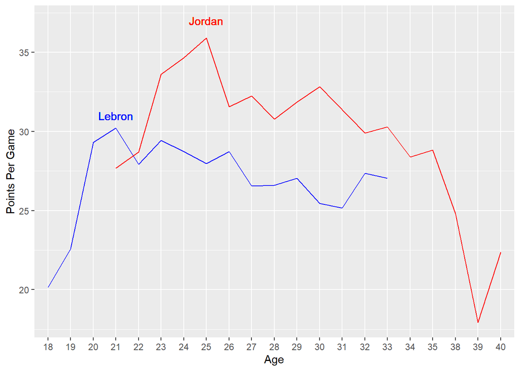

```r
lebron_points<-lebron%>%
  group_by(Age_Year)%>%
  summarise(PPG=mean(pts,na.rm =TRUE))
jordan_points<-jordan%>%
  group_by(Age_Year)%>%
  summarise(PPG=mean(pts,na.rm =TRUE))
PPG_Comparison<-ggplot()+
  geom_line(data = lebron_points, aes(x = Age_Year, y = PPG,group=1), color = "blue") +
  geom_text(data=lebron_points, aes(x = "21",y=31,group=1),label="Lebron",color="blue") +
  geom_line(data = jordan_points, aes(x = Age_Year, y = PPG,group=1), color = "red") +
  geom_text(data = jordan_points, aes(x = "25",y=37,group=1),label="Jordan",color="red") +
  xlab('Age') +
  ylab('Points Per Game')
print(PPG_Comparison)
```

## Comparing LeBron’s number of wins and losses.

```r
lebron_record<-lebron%>%
  group_by(team)%>%
  summarise(Wins=sum(result=="W"),
            Losses=sum(result=="L"),
            Win_Percent=(sum(result=="W")/length(result)),
            Games=n(),
            .groups = "drop")
lebron_record
```

```
## # A tibble: 2 × 5
##   team   Wins Losses Win_Percent Games
##   <chr> <int>  <int>       <dbl> <int>
## 1 CLE     538    300       0.642   838
## 2 MIA     215     79       0.731   294
```

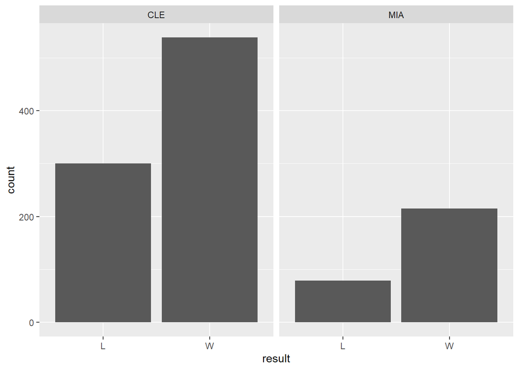

```r
lebron_record1<-lebron%>%
  group_by(team)%>%
  summarise(Wins=sum(result=="W"),
            Losses=sum(result=="L"),
            Win_Percent=(sum(result=="W")/length(result)),
            Games=n(),
            result,
            .groups = "drop")
ggplot(lebron_record1,mapping=aes(x=result))+geom_bar(stat = "count")+facet_grid(~team)
```

## The bar graph shows that LeBron has played many more games in Cleveland than in Miami. LeBron played a total of 838 game in Cleveland and 294 games in Miami. Though he played less games in Miami, he does have a better win percentage of 73.1% than his win percentage of 64.2% in Cleveland. (Data doesn’t account for his current team in Los Angeles)

```r
jordan_record<-jordan%>%
  group_by(team)%>%
  summarise(Wins=sum(result=="W"),
            Losses=sum(result=="L"),
            Win_Percent=(sum(result=="W")/length(result)),
            Games=n(),
            .groups = "drop")
jordan_record
```

```
## # A tibble: 2 × 5
##   team   Wins Losses Win_Percent Games
##   <chr> <int>  <int>       <dbl> <int>
## 1 CHI     639    291       0.687   930
## 2 WAS      67     75       0.472   142
```

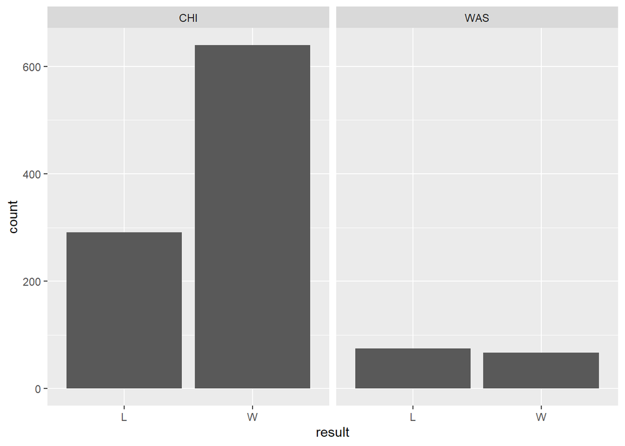

```r
jordan_record1<-jordan%>%
  group_by(team)%>%
  summarise(Wins=sum(result=="W"),
            Losses=sum(result=="L"),
            Win_Percent=(sum(result=="W")/length(result)),
            Games=n(),
            result,
            .groups = "drop")
ggplot(jordan_record1,mapping=aes(x=result))+geom_bar(stat = "count")+facet_grid(~team)
```

## Jordan played a total of 930 games in Chicago and 142 games in Washington. He had a win percentage of 68.7% in Chicago and 47.2% in Washington. Jordan had a negative record of 67-75 in Washington most likely due to his age. Comparing both bar plots, LeBron seemed to have the more superior win percentage in Miami than Jordan on any of his teams.

## Plotting LeBron’s average Plus Minus throughout each year of his career.

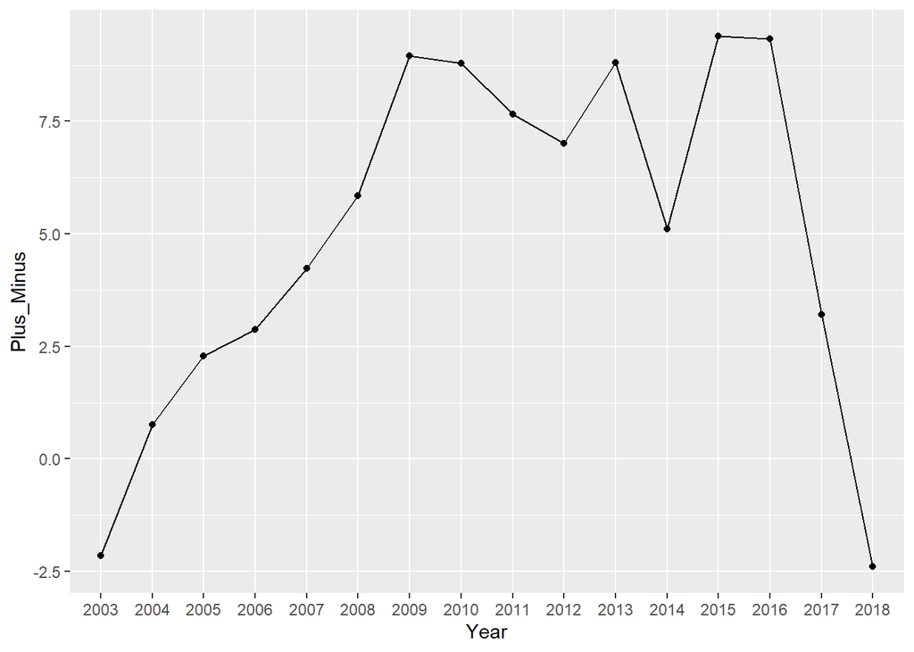

```r
lebron_plus_minus<-lebron%>%
  mutate(Plus_Minus=minus_plus)%>%
  group_by(Year)%>%
  summarise(Plus_Minus=mean(minus_plus))
ggplot(lebron_plus_minus,mapping = aes(x=Year,y=Plus_Minus,group=1))+geom_point()+geom_line()
```

## Plus minus in basketball is defined as the point differential between you and the opposing team while you are playing on the court. This is used to determine the effectiveness of the player when they are playing. LeBron’s average plus minus was from 2008-2016 showing his peak years of play. The plot also shows how he improved from his rookie season and how he fell behind once he started to get much older. He had a positive plus minus for most of his career showing how important he was towards his team’s success. Unfortunately, the Jordan data set doesn’t have the plus minus for his games.

## This analysis used very basic stats in trying to understand who is better between LeBron James and Michael Jordan. The analyis could go in depth with many more pieces of statistics that were recorded throughout their careers. One thing however that was proven through this analysis, Jordan and LeBron are two of the greatest basketball players to ever play the game and their statistics prove that they are very comparable. At the end of the day, both players clearly have evidence that supports why one is greater than the other.